# Lição GitHub nº 5

Construindo gráficos com ggplot2

Maiara Jesus Souza

(10/02/2022)

## Introdução

Como solicitado pela disciplina Estat. 2021.1, nesse repositório construiremos 6 tipos de gráficos, dentre eles Gráfico de Pontos, Gráfico de Linhas, Gráfico de Colunas, Histograma, Gráfico de Densidade e Boxplot, com pacote ggplot2, utilizando *dataset, frango_dieta.csv e gordura_corporal.csv*.

### Caregando o “tidyverse”

```r
library(tidyverse)
```

### Lendo os dados

```r
library(readr)
gordura_corporal <- read_csv("dados/gordura_corporal.csv")
View(gordura_corporal)
```

```r
frango_dieta <- read_csv("dados/frango_dieta.csv")
View(frango_dieta)
```

## 1. Gráfico de Pontos;

- dataset(gordura_corporal)

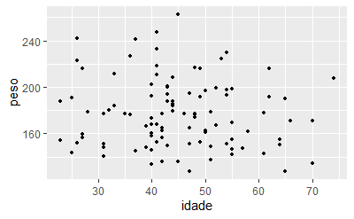

```r
ggplot(gordura_corporal) +
  aes(x = idade, y = peso) +
  geom_point(size = 1)
```

##### Resposta: o Gráfico de Pontos, expõem que indevidos com idade entre 40 á 50 anos, tem um índice de peso mais elevado, pela concentração dos pontos nessas idades.

## 2. Gráfico de Linhas;

- dataset(gordura_corporal)

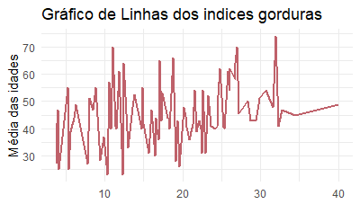

```r
gordura_corporal %>%
  group_by(indice_gordura) %>%
  summarise(
    media_idade = round(mean(idade), 1)
  ) %>%
  ggplot(aes(x = indice_gordura, y = media_idade, group = 1)) +
  geom_line(color = "#BF616A", size = 1) +
  labs(
    title = "Gráfico de Linhas dos indices gorduras ",
    x = "",
    y = "Média das idades"
  ) +
  theme_minimal()
```

#### Resposta: o Gráfico de Linhas, expõem que á um aumento considerável com indevidos com 50 anos ou mais, tem índices de gordura elevados.

## 3. Gráfico de Colunas (ou de Barras);

- dataset(gordura_corporal)

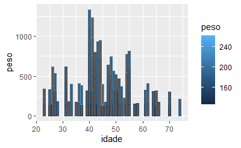

```r
gordura_corporal %>%
  count(idade, peso) %>%
  ggplot(aes(x = idade, y = peso, color = peso)) +
  geom_col()
```

#### Resposta: o Gráfico de Colunas (ou de Barras), expõem como no gráfico de pontos, que indevidos com idade entre 40 á 50 anos, tem um índice de peso mais elevado.

## 4. Histograma;

- dataset(frango_dieta)

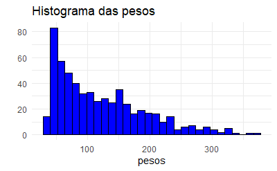

```r
frango_dieta %>%
  ggplot() +
  aes(x = peso) +
  geom_histogram(fill = "blue", color = "black") +
  labs(
    title = "Histograma das pesos",
    x = "pesos",
    y = ""
  ) +
  theme_minimal()
```

#### Resposta: o Histograma, expõem que á um aumento considerável com pesos abaixo de 100, e um decaimento pra pesos acima desse valor.

## 5. Gráfico de Densidade;

- dataset(gordura_corporal)

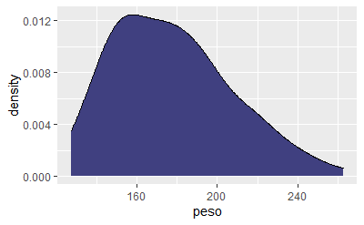

```r
gordura_corporal %>%
  ggplot() +
  aes(x = peso ) +
  geom_density(fill = "#404080")
```

```r
NA
```

#### Resposta: o Gráfico de Densidade, expõem que á um aumento considerável com indevidos de pesos entre 150 á 200.

## 6. Boxplot.

- dataset(frango_dieta)

```r
frango_dieta %>%
  ggplot() +
  aes(x = tempo, y= peso) +
  geom_boxplot(aes(fill = tempo), show.legend = FALSE) +
  scale_fill_viridis_d()
```

[figure not shown]

#### resposta: o Boxplot expõem que a média dos dados frango, do peso é aproximadamente 100.